# Niveles de servicio y gestión de incidentes.

[figure not shown]

### José Luis Chiquete Valdvieso

### Noviembre 2022

# ¿Qué es un prueba de software?

### `"La prueba de software es el proceso de evaluar y verificar que un producto o aplicación de software hace lo que se supone que debe hacer. Los beneficios de las pruebas incluyen la prevención de errores, la reducción de los costos de desarrollo y la mejora del rendimiento."`

# Deuda técnica.

Es el costo que implica retrabajar un artefacto por causas de su pobre desarrollo en etapas tempranas del ciclo de vida.

[figure not shown]

### `“El costo es más importante que la calidad, pero la calidad es la mejor manera de reducir el costo.”` — Genichi Taguchi

# Desarrollo Dirigido por Pruebas (*TDD*).

- Es una práctica cuyo objetivos es lograr un código limpio, seguro y que funcione.
- La idea es que los requerimientos sean traducidos en pruebas. De este modo, cuando las pruebas pasen se garantizará que el software cumple con los requerimientos funcionales y no funcionales que se han establecido.

## Escribir las pruebas primero (*Test First Development*).

- Consiste en crear pruebas para cada funcionalidad que debe cumplir el producto de software.

## El ciclo de vida de *TDD*.

[figure not shown]

Fuente: https://upload.wikimedia.org/wikipedia/commons/0/0b/TDD_Global_Lifecycle.png

## Aseguramiento de la calidad (*QA*).

- El concepto de *QA* implica una serie de métodos y actividades cuyo objetivo es garantizar que el software cumple con las especificaciones requeridas.
- Las actividades de *QA* también requieren de la realización de pruebas y análisis del código y los binarios durante el ciclo de vida de desarrollo de software.

# Tipos de pruebas.

## Pruebas funcionales.

Fuente: https://hackr.io/blog/types-of-software-testing

- **Pruebas unitarias.** Evalúan el correcto funcionamiento de cada componente de código.
  - **mock** es un objeto que simula las características de un objeto real y que es utilizado para realizar las pruebas unitarias.
  - **stub** es un objeto que permite emular las interfaces, formatos y respuestas predeterminadas de un sistema externo, de tal forma que se puedan realizar pruebas en un entorno simplificado.
  - **code coverage** es el procentaje de código que es sujeto de prueba durante la ejecución de las pruebas unitarias.
- **Pruebas de integración.** Evalúan el funcionamiento del sistema a partir de la inclusión de nuevos componentes.
- **Pruebas de extremo a extremo**. Evalúa que cada componente de software de un proceso funciones correctamente de principio a fin.
- **Pruebas de humo**. Son pruebas no exhaustivas que se le hacen a un producto de software previo a su liberación a producción para validar que las funcionalidades primordiales funcionan correctamente.
- **Pruebas de aceptación (*UAT*)**. Son pruebas que validan la funcionalidad del producto ante el cliente.
- **Pruebas de regresión**. Son pruebas exhaustivas que se hacen para validar que el sistema funciona correctamente después de cierto tiempo de estar en producción.

## Pruebas no funcionales.

- **Pruebas de seguridad**. Evalúan las posibles vulnerabilidades de un sistema.
- **Pruebas de compatibilidad**. Evalúan si un sistema puede interactuar adecuadamente con otros.
- **Pruebas de rendimiento**. Evalúan el uso de recursos de un sistema.
- **Pruebas de escalabilidad**. Evalúan la capacidad de crecer en cuestión de recursos de un sistema.
- **Pruebas de carga**. Evalúan la capacidad de un sistema ante cierto tipo de cargas de uso.
- **Pruebas de volumen**. Evalúan la capacidad de un sistema de gestionar grandes cantidades de datos.
- **Pruebas de fallo**. Evalúan la resiliencia de un sistema.
- **Pruebas de estrés**. Evalúan el comportamiento de un sistema cuando se encuentra al límite de sus capacidades.
- **Pruebas de resistencia**. Evalúa la operación del sistema con cargas máximas en tiempos largos.
- **Pruebas de recuperación ante desastres**. Evalúa la capacidad de un sistema para restablecer sus funcionalidades en caso de una emergencia crítica, así como de mitgar riesgos.
- **Pruebas de eficiencia**. Evalúan si el sistema cumple con los objetivos funcionales en tiempo razonable.
- **Pruebas de mantenibilidad**. Evalúan la facilidad de mantenimiento de un sistema.
- **Pruebas de usabilidad**. Evalúan la experiencia general del uso de un sistema.
- **Pruebas de cumplimiento (compliance)**. Evalúan si un sistema cumple con la normatividad aplicable.
- **Pruebas de confiabilidad** Evalúan la disponibilidad y madurez de los procesos dentro del sistema.
- **Pruebas de localización**. Evalúa la capacidad de un sistema de poder ofercer servicios homogeneos a usuarios de diversas zonas geográficas.
- **Pruebas de internacionalización**. Evalúa la capacidad de un sistema de poder ofercer servicios homogeneos a usuarios de diversas zonas geográficas a novel internacional.

# Las pruebas en *DevSecOps*.

- *DevSecOps* consiste en automatizar y grantizar la seguridad de todo aquello que no agrega valor, con la finalidad de que los equipos de trabajo multidisciplinarios se enfoquen en actividades que enriquezcan al producto de software.

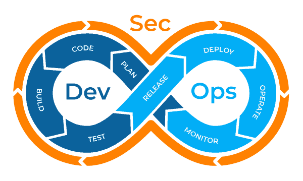

- Bajo la premisa de *DevSecOps*, las pruebas son parte fundamental de un *pipeline* de *CI/CD*.

# Pruebas de despliegue.

- **A/B testing**. Consiste en comparar dos versiones de una misma página web o aplicación para comprobar cuál de las dos versiones es más eficiente. Su objetivo principal es el de experimentar nuevas funcionalidades.
- **Blue green deployment**. es un modelo de liberación que transfiere gradualmente el tráfico de usuarios de una versión previa de una aplicación (*blue*) a una nueva versión prácticamente idéntica (*green*). Ambas versiones están desplegadas en producción.
- **Canary deployment**. es un modelo de liberación que expone a un pequeño y selecto grupo de usuarios a una nueva versión de una aplicación en producción.

# Desarrollo dirigido por comportamiento (*BDD*).

- *BDD* es un proceso propio de desarrollo ágil, el cual permite facilitar la interacción entre los desarrolladores, testers y *QA* con los clientes.
- Consiste en "traducir" las especificaciones de un sistema descritas en lenguaje coloquial a código capaz de evaluar dichas especificaciones.

### Gherkin.

Gherkin es un lenguaje de dominio específico que permite ligar ciertas palabras que definen funcionalidades, escenarios, condiciones y acciones descritas en lenguaje natural que pueden ser transformadas en métodos o funciones de prueba.

https://www.itdo.com/blog/ejemplos-bdd-behavior-driven-development-con-gherkin/

[figure not shown]

Esta obra está bajo una [Licencia Creative Commons Atribución 4.0 Internacional](http://creativecommons.org/licenses/by/4.0/).

© José Luis Chiquete Valdivieso. 2022.